# DADA2 Pipeline

## Analyses Start Point

Conditions: 1. Samples have been multiplexed (we have per sample fastq files). 2. Non-biological nucleotides have been removed (primers, adapters, linkers). 3. Forward and Reverse fastq files contain reads in matched order.

### Load packages

If you don’t have the package, you need to install first.

```r
library(Rcpp)
library(dada2)
library(unix)
library(writexl)
library(phyloseq)
library(phangorn)
library(ggplot2)
library(DESeq2)
library(metagMisc)
library(vegan)
library(tidyverse)
library(patchwork)
library(cowplot)
library(DECIPHER)
```

```r
rlimit_as(1e15) #expand memory allocation depending on data size
rlimit_all() # check memory
```

The fastq files used were generated by 2*300 bp V3-V4 Illumina Miseq amplicon sequencing of the 16S rRNA gene from water, hemocyte, gill and stomach collected from seemingly healthy and WSSV infected Kuruma Shrimps to assess the microbiota profile.

The path to the paired end fastq files;

```r
path <- "~/DADA2/Koiwai16S/data" # CHANGE ME to the directory containing the fastq files after unzipping.
list.files(path)
```

```
 [1] "filtered"                              "metadata2.csv"                         "metadata2.txt"                         "S221_L001_R1_001.fastq.gz"
 [5] "S221_L001_R2_001.fastq.gz"             "S222_L001_R1_001.fastq.gz"             "S222_L001_R2_001.fastq.gz"             "S223_L001_R1_001.fastq.gz"
 [9] "S223_L001_R2_001.fastq.gz"             "S224_L001_R1_001.fastq.gz"             "S224_L001_R2_001.fastq.gz"             "S225_L001_R1_001.fastq.gz"
[13] "S225_L001_R2_001.fastq.gz"             "S226_L001_R1_001.fastq.gz"             "S226_L001_R2_001.fastq.gz"             "S227_L001_R1_001.fastq.gz"
[17] "S227_L001_R2_001.fastq.gz"             "S228_L001_R1_001.fastq.gz"             "S228_L001_R2_001.fastq.gz"             "S229_L001_R1_001.fastq.gz"
[21] "S229_L001_R2_001.fastq.gz"             "S230_L001_R1_001.fastq.gz"             "S230_L001_R2_001.fastq.gz"             "S231_L001_R1_001.fastq.gz"
[25] "S231_L001_R2_001.fastq.gz"             "S232_L001_R1_001.fastq.gz"             "S232_L001_R2_001.fastq.gz"             "S233_L001_R1_001.fastq.gz"
[29] "S233_L001_R2_001.fastq.gz"             "S234_L001_R1_001.fastq.gz"             "S234_L001_R2_001.fastq.gz"             "S235_L001_R1_001.fastq.gz"
[33] "S235_L001_R2_001.fastq.gz"             "S236_L001_R1_001.fastq.gz"             "S236_L001_R2_001.fastq.gz"             "S237_L001_R1_001.fastq.gz"
[37] "S237_L001_R2_001.fastq.gz"             "S238_L001_R1_001.fastq.gz"             "S238_L001_R2_001.fastq.gz"             "S239_L001_R1_001.fastq.gz"
[41] "S239_L001_R2_001.fastq.gz"             "S240_L001_R1_001.fastq.gz"             "S240_L001_R2_001.fastq.gz"             "silva_nr99_v138.1_train_set.fa.gz"
[45] "silva_species_assignment_v138.1.fa.gz" "SILVA_SSU_r138_2019.RData"
```

### Read in the names of fastq files

This was performed to get matched lists of the forward and reverse fastq files.

```r
# Forward and reverse fastq filenames have format: SAMPLENAME_R1_001.fastq and SAMPLENAME_R2_001.fastq
fnFs <- sort(list.files(path, pattern="_R1_001.fastq", full.names = TRUE))
fnRs <- sort(list.files(path, pattern="_R2_001.fastq", full.names = TRUE))
# Extract sample names, assuming filenames have format: SAMPLENAME_XXX.fastq
sample.names <- sapply(strsplit(basename(fnFs), "_"), `[`, 1)
```

## Inspect read quality profiles

Here we visualize the quality profiles of the forward reads:

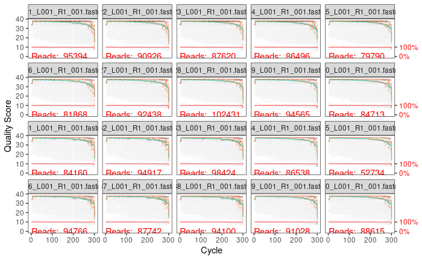

In gray-scale is a heat map of the frequency of each quality score at each base position. The mean quality score at each position is shown by the green line, and the quartiles of the quality score distribution by the orange lines. The red line shows the scaled proportion of reads that extend to at least that position.

Here we visualize the quality profiles of the reverse reads:

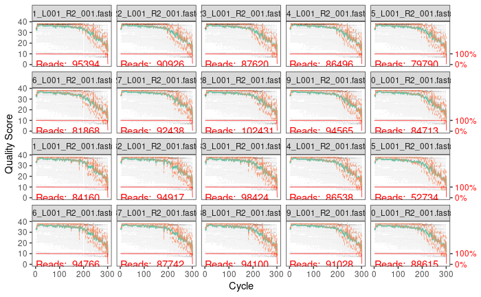

Check forward reads length distribution

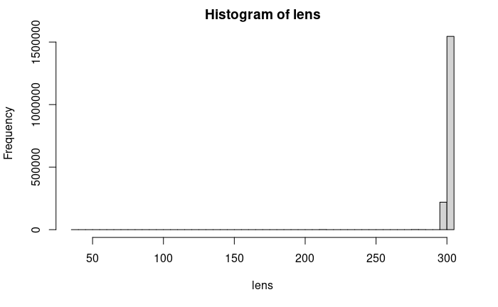

Check reverse reads length distribution

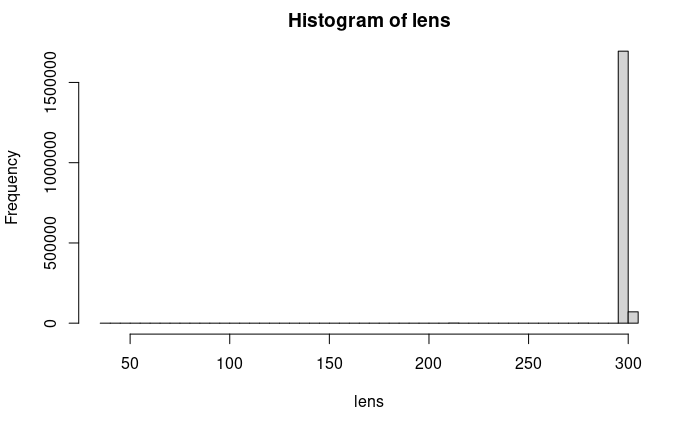

## Filter and trim

Assign filter names for the filtered fastq.gz files

```r
# Place filtered files in filtered/ subdirectory
filtFs <- file.path(path, "filtered", paste0(sample.names, "_F_filt.fastq.gz"))
filtRs <- file.path(path, "filtered", paste0(sample.names, "_R_filt.fastq.gz"))
names(filtFs) <- sample.names
names(filtRs) <- sample.names
```

We’ll use standard filtering parameters: maxN=0 (DADA2 requires no Ns), truncQ=2, rm.phix=TRUE and maxEE=2. The maxEE parameter sets the maximum number of “expected errors” allowed in a read, which is a better filter than simply averaging quality scores.

```r
out <- filterAndTrim(fnFs, filtFs, fnRs, filtRs, truncLen=c(280,200),
              maxN=0, maxEE=c(2,2), truncQ=2, rm.phix=TRUE,
              compress=TRUE, trimLeft=10, multithread=TRUE)
head(out)
```

```
                          reads.in reads.out
S221_L001_R1_001.fastq.gz    95394     83927
S222_L001_R1_001.fastq.gz    90926     79578
S223_L001_R1_001.fastq.gz    87620     76515
S224_L001_R1_001.fastq.gz    86496     75757
S225_L001_R1_001.fastq.gz    79790     70127
S226_L001_R1_001.fastq.gz    81868     70240
```

Considerations for your own data: The standard filtering parameters are starting points, not set in stone. If you want to speed up downstream computation, consider tightening maxEE. If too few reads are passing the filter, consider relaxing maxEE, perhaps especially on the reverse reads (eg. maxEE=c(2,5)), and reducing the truncLen to remove low quality tails. Remember though, when choosing truncLen for paired-end reads you must maintain overlap after truncation in order to merge them later.

## Learn the Error Rates

The DADA2 algorithm makes use of a parametric error model (err) and every amplicon dataset has a different set of error rates. The learnErrors method learns this error model from the data, by alternating estimation of the error rates and inference of sample composition until they converge on a jointly consistent solution. As in many machine-learning problems, the algorithm must begin with an initial guess, for which the maximum possible error rates in this data are used (the error rates if only the most abundant sequence is correct and all the rest are errors). Forward errors

```r
errF <- learnErrors(filtFs, multithread=TRUE)
```

```
104194080 total bases in 385904 reads from 5 samples will be used for learning the error rates.
```

Reverse errors

```r
errR <- learnErrors(filtRs, multithread=TRUE)
```

```
102240710 total bases in 538109 reads from 7 samples will be used for learning the error rates.
```

Visualize estimated errors

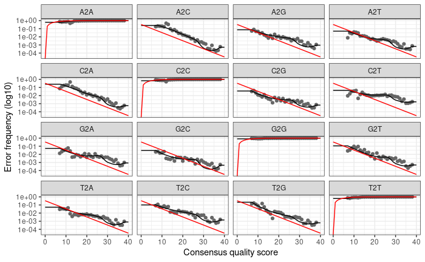

The error rates for each possible transition (A→C, A→G, …) are shown. Points are the observed error rates for each consensus quality score. The black line shows the estimated error rates after convergence of the machine-learning algorithm. The red line shows the error rates expected under the nominal definition of the Q-score. Here the estimated error rates (black line) are a good fit to the observed rates (points), and the error rates drop with increased quality as expected. Everything looks reasonable and we proceed with confidence.

## Sample Inference

Here we apply the core sample inference algorithm to the filtered and trimmed sequence data.

```r
dadaFs <- dada(filtFs, err=errF, multithread=TRUE)
```

```
Sample 1 - 83927 reads in 16154 unique sequences.
Sample 2 - 79578 reads in 16490 unique sequences.
Sample 3 - 76515 reads in 14930 unique sequences.
Sample 4 - 75757 reads in 14437 unique sequences.
Sample 5 - 70127 reads in 13743 unique sequences.
Sample 6 - 70240 reads in 12329 unique sequences.
Sample 7 - 81965 reads in 20335 unique sequences.
Sample 8 - 90345 reads in 18490 unique sequences.
Sample 9 - 84556 reads in 17567 unique sequences.
Sample 10 - 74155 reads in 25203 unique sequences.
Sample 11 - 74355 reads in 9086 unique sequences.
Sample 12 - 83481 reads in 7370 unique sequences.
Sample 13 - 84747 reads in 10790 unique sequences.
Sample 14 - 75119 reads in 23634 unique sequences.
Sample 15 - 45065 reads in 9220 unique sequences.
Sample 16 - 82865 reads in 10291 unique sequences.
Sample 17 - 77434 reads in 10602 unique sequences.
Sample 18 - 81186 reads in 11924 unique sequences.
Sample 19 - 79992 reads in 24871 unique sequences.
Sample 20 - 76518 reads in 21470 unique sequences.
```

```r
dadaRs <- dada(filtRs, err=errR, multithread=TRUE)
```

```
Sample 1 - 83927 reads in 11274 unique sequences.
Sample 2 - 79578 reads in 12275 unique sequences.
Sample 3 - 76515 reads in 13188 unique sequences.
Sample 4 - 75757 reads in 11009 unique sequences.
Sample 5 - 70127 reads in 12406 unique sequences.
Sample 6 - 70240 reads in 11053 unique sequences.
Sample 7 - 81965 reads in 14727 unique sequences.
Sample 8 - 90345 reads in 17466 unique sequences.
Sample 9 - 84556 reads in 15112 unique sequences.
Sample 10 - 74155 reads in 19542 unique sequences.
Sample 11 - 74355 reads in 7124 unique sequences.
Sample 12 - 83481 reads in 6658 unique sequences.
Sample 13 - 84747 reads in 8454 unique sequences.
Sample 14 - 75119 reads in 19024 unique sequences.
Sample 15 - 45065 reads in 10024 unique sequences.
Sample 16 - 82865 reads in 8638 unique sequences.
Sample 17 - 77434 reads in 8327 unique sequences.
Sample 18 - 81186 reads in 9864 unique sequences.
Sample 19 - 79992 reads in 19505 unique sequences.
Sample 20 - 76518 reads in 18071 unique sequences.
```

Inspecting the returned ‘dada-class’ object:

```r
dadaFs[[1]]
```

```
dada-class: object describing DADA2 denoising results
298 sequence variants were inferred from 16154 input unique sequences.
Key parameters: OMEGA_A = 1e-40, OMEGA_C = 1e-40, BAND_SIZE = 16
```

The DADA2 algorithm inferred 298 true sequence variants from the 16154 unique sequences in the first sample.

## Merge paired reads

We now merge the forward and reverse reads together to obtain the full denoised sequences. Merging is performed by aligning the denoised forward reads with the reverse-complement of the corresponding denoised reverse reads, and then constructing the merged “contig” sequences. By default, merged sequences are only output if the forward and reverse reads overlap by at least 12 bases, and are identical to each other in the overlap region (but these conditions can be changed via function arguments).

```r
mergers <- mergePairs(dadaFs, filtFs, dadaRs, filtRs, verbose=TRUE)
```

```
80900 paired-reads (in 1009 unique pairings) successfully merged out of 82636 (in 2154 pairings) input.
75493 paired-reads (in 1018 unique pairings) successfully merged out of 77967 (in 2454 pairings) input.
72783 paired-reads (in 741 unique pairings) successfully merged out of 74798 (in 2020 pairings) input.
73313 paired-reads (in 554 unique pairings) successfully merged out of 74704 (in 1421 pairings) input.
65947 paired-reads (in 864 unique pairings) successfully merged out of 68398 (in 2405 pairings) input.
68219 paired-reads (in 684 unique pairings) successfully merged out of 69337 (in 1283 pairings) input.
75023 paired-reads (in 1647 unique pairings) successfully merged out of 77905 (in 3570 pairings) input.
86424 paired-reads (in 1631 unique pairings) successfully merged out of 88047 (in 2699 pairings) input.
81205 paired-reads (in 1628 unique pairings) successfully merged out of 82445 (in 2369 pairings) input.
62360 paired-reads (in 2396 unique pairings) successfully merged out of 67414 (in 5640 pairings) input.
73528 paired-reads (in 914 unique pairings) successfully merged out of 73927 (in 1148 pairings) input.
82901 paired-reads (in 344 unique pairings) successfully merged out of 83210 (in 479 pairings) input.
84065 paired-reads (in 931 unique pairings) successfully merged out of 84258 (in 1087 pairings) input.
63523 paired-reads (in 2185 unique pairings) successfully merged out of 69050 (in 5375 pairings) input.
42913 paired-reads (in 972 unique pairings) successfully merged out of 43889 (in 1273 pairings) input.
81981 paired-reads (in 983 unique pairings) successfully merged out of 82537 (in 1262 pairings) input.
76789 paired-reads (in 1101 unique pairings) successfully merged out of 77065 (in 1283 pairings) input.
79792 paired-reads (in 892 unique pairings) successfully merged out of 80370 (in 1244 pairings) input.
70441 paired-reads (in 2563 unique pairings) successfully merged out of 74098 (in 5034 pairings) input.
65936 paired-reads (in 2120 unique pairings) successfully merged out of 71389 (in 4366 pairings) input.
```

```r
# Inspect the merger data.frame from the first sample
head(mergers[[1]])
```

|  | sequence | abundance | forward | reverse | nmatch | nmismatch | nindel | prefer | accept |
| --- | --- | --- | --- | --- | --- | --- | --- | --- | --- |
| 1 | GGCTGCAGTGAGGAATATTGGACAATGGGTGAGAGCCTGATCCAGCCATCCCGCGTGAAG…… | 6352 | 1 | 2 | 18 | 0 | 0 | 2 | TRUE |
| 2 | GGCAGCAGTGAGGAATATTGGACAATGGGTGAGAGCCTGATCCAGCCATCCCGCGTGAAG…… | 4940 | 2 | 2 | 18 | 0 | 0 | 2 | TRUE |
| 3 | GGCTGCAGTGGGGAATATTGCACAATGGGGGAAACCCTGATGCAGCCATGCCGCGTGTGT…… | 4699 | 3 | 1 | 13 | 0 | 0 | 2 | TRUE |
| 4 | GGCAGCAGTGGGGAATATTGCACAATGGGGGAAACCCTGATGCAGCCATGCCGCGTGTGT…… | 3763 | 4 | 1 | 13 | 0 | 0 | 2 | TRUE |
| 5 | GGCTGCAGTGGGGAATATTGCACAATGGGCGCAAGCCTGATGCAGCCATGCCGCGTGTAT…… | 1939 | 5 | 4 | 13 | 0 | 0 | 2 | TRUE |
| 6 | GGCTGCAGTGGGGAATATTGGACAATGGGCGAAAGCCTGATCCAGCCATGCCGCGTGTGT…… | 1937 | 6 | 6 | 13 | 0 | 0 | 2 | TRUE |

The mergers object is a list of data.frames from each sample. Each data.frame contains the merged $sequence, it’s $abundance, and the indices of the $forward and $reverse sequence variants that were merged. Paired reads that did not exactly overlap were removed by mergePairs, further reducing spurious output. Considerations for your own data: Most of your reads should successfully merge. If that is not the case upstream parameters may need to be revisited: Did you trim away the overlap between your reads?

## Construct sequence Table

We can now construct an amplicon sequence variant table (ASV) table

```r
seqtab <- makeSequenceTable(mergers)
dim(seqtab)
```

```
[1]    20 17099
```

```r
# Inspect distribution of sequence lengths
table(nchar(getSequences(seqtab)))
```

```
 270  279  280  281  282  292  297  299  310  317  323  324  345  355  359  364  370  377  378  387  391  393  396  400  401  403  404  405  406  407  408  409  415  416
   6    2   44    3    1    1    1    3    3    1    1    1    1    1    2    3   40    1    1    1    2    3    2    1    1   20   13   46   21   15    5    4    1    1
 417  419  420  421  422  423  424  425  426  427  428  429  430  431  432  433  434  435  436  437  438  439  440  441  442  443  444  445  446  447  448
   1   11   10   62 2180  589  187  128   93  230   25   64   20    8    6   10    8   14   13   24   15   21  158  183 1332  213  437   49  392 9125 1239
```

The sequence table is a matrix with rows corresponding to (and named by) the samples, and columns corresponding to (and named by) the sequence variants. This table contains 17099 ASVs, and the lengths of our merged sequences (majority) fall within the expected range for this V3-V4 amplicon 440-470 bp.

###Distribution of sequence length plot

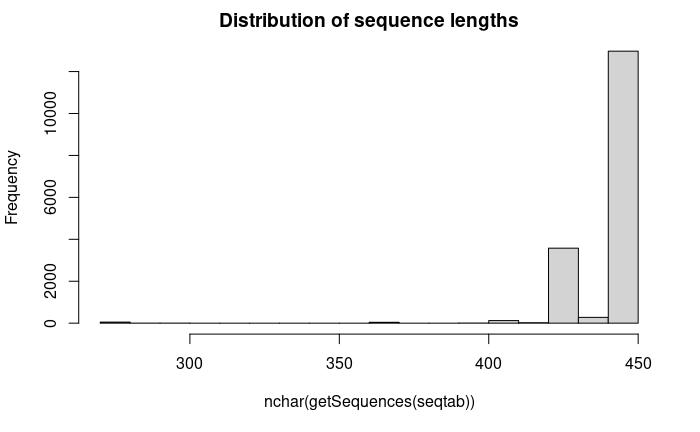

## Remove chimeras

The core dada method corrects substitution and indel errors, but chimeras remain. Fortunately, the accuracy of sequence variants after denoising makes identifying chimeric ASVs simpler than when dealing with fuzzy OTUs. Chimeric sequences are identified if they can be exactly reconstructed by combining a left-segment and a right-segment from two more abundant “parent” sequences.

```r
seqtab.nochim <- removeBimeraDenovo(seqtab, method="consensus", multithread=TRUE, verbose=TRUE)
```

```
Identified 9590 bimeras out of 17099 input sequences.
```

```r
dim(seqtab.nochim)
```

```
[1]   20 7509
```

Chimera sequences frequency

```r
sum(seqtab.nochim)/sum(seqtab)
```

```
[1] 0.919661
```

The frequency of chimeric sequences varies substantially from dataset to dataset, and depends on factors including experimental procedures and sample complexity. Here chimeras make up about 56 % of the merged sequence variants, but when we account for the abundances of those variants we see they account for only about 8% of the merged sequence reads.

Considerations: Most of your reads should remain after chimera removal (it is not uncommon for a majority of sequence variants to be removed though). If most of your reads were removed as chimeric, upstream processing may need to be revisited. In almost all cases this is caused by primer sequences with ambiguous nucleotides that were not removed prior to beginning the DADA2 pipeline.

## Track reads through the pipeline

```r
getN <- function(x) sum(getUniques(x))
track <- cbind(out, sapply(dadaFs, getN), sapply(dadaRs, getN), sapply(mergers, getN), rowSums(seqtab.nochim))
# If processing a single sample, remove the sapply calls: e.g. replace sapply(dadaFs, getN) with getN(dadaFs)
colnames(track) <- c("input", "filtered", "denoisedF", "denoisedR", "merged", "nonchim")
rownames(track) <- sample.names
head(track)
```

```
     input filtered denoisedF denoisedR merged nonchim
S221 95394    83927     82925     83601  80900   72563
S222 90926    79578     78318     79171  75493   65465
S223 87620    76515     75240     76043  72783   68248
S224 86496    75757     74997     75434  73313   68250
S225 79790    70127     68781     69710  65947   61775
S226 81868    70240     69598     69957  68219   63126
```

Considerations: This is a great place to do a last sanity check. Outside of filtering, there should no step in which a majority of reads are lost. If a majority of reads failed to merge, you may need to revisit the truncLen parameter used in the filtering step and make sure that the truncated reads span your amplicon. If a majority of reads were removed as chimeric, you may need to revisit the removal of primers, as the ambiguous nucleotides in unremoved primers interfere with chimera identification.

## Assign Taxonomy

It is common at this point, especially in 16S/18S/ITS amplicon sequencing, to assign taxonomy to the sequence variants.The dada2 package implements the naive Bayesian classifier method for this purpose (Wang et al. 2007). The assignTaxonomy function takes as input a set of sequences to be classified and a training set of reference sequences with known taxonomy, and outputs taxonomic assignments with at least minBoot bootstrap confidence.

The training fasta files used for this analyses are derived from the Silva Project’s version 138.1 release and formatted for use with DADA2. These files are intended for use in classifying prokaryotic 16S sequencing data and are not appropriate for classifying eukaryotic ASVs.

```r
taxa <- assignTaxonomy(seqtab.nochim, "~/DADA2/Koiwai16S/data/silva_nr99_v138.1_train_set.fa.gz", multithread=TRUE)
```

Assign species

```r
taxa <- addSpecies(taxa, "~/DADA2/Koiwai16S/data/silva_species_assignment_v138.1.fa.gz")
```

Inspect the taxonomic assignment

```r
taxa.print <- taxa # Removing sequence rownames for display only. Use (taxa.print <- taxasp) to include the species classification.
rownames(taxa.print) <- NULL
head(taxa.print)
```

```
     Kingdom    Phylum           Class                 Order              Family             Genus            Species
[1,] "Bacteria" "Proteobacteria" "Gammaproteobacteria" "Enterobacterales" "Vibrionaceae"     "Photobacterium" NA
[2,] "Bacteria" "Proteobacteria" "Gammaproteobacteria" "Enterobacterales" "Vibrionaceae"     "Photobacterium" "damselae"
[3,] "Bacteria" "Proteobacteria" "Gammaproteobacteria" "Pseudomonadales"  "Pseudomonadaceae" "Pseudomonas"    NA
[4,] "Bacteria" "Proteobacteria" "Gammaproteobacteria" "Enterobacterales" "Vibrionaceae"     "Vibrio"         NA
[5,] "Bacteria" "Proteobacteria" "Gammaproteobacteria" "Pseudomonadales"  "Pseudomonadaceae" "Pseudomonas"    NA
[6,] "Bacteria" "Proteobacteria" "Gammaproteobacteria" "Enterobacterales" "Vibrionaceae"     "Vibrio"         "nigripulchritudo"
```

From the on look, proteobacteria phylum are well represented. Seemingly the most abundant taxa in our Kuruma Shrimp samples. Few species assignments were made, both because it is often not possible to make unambiguous species assignments from sub-segments of the 16S gene, and because there is surprisingly little coverage of the indigenous kuruma shrimp associated microbiota in reference databases.

```r
taxtable <- data.frame(taxa.print)#make dataframe
taxtable
```

| Kingdom | Phylum | Class | Order | Family | Genus | Species |
| --- | --- | --- | --- | --- | --- | --- |
| Bacteria | Proteobacteria | Gammaproteobacteria | Enterobacterales | Vibrionaceae | Photobacterium | NA |
| Bacteria | Proteobacteria | Gammaproteobacteria | Enterobacterales | Vibrionaceae | Photobacterium | damselae |
| Bacteria | Proteobacteria | Gammaproteobacteria | Pseudomonadales | Pseudomonadaceae | Pseudomonas | NA |
| Bacteria | Proteobacteria | Gammaproteobacteria | Enterobacterales | Vibrionaceae | Vibrio | NA |
| Bacteria | Proteobacteria | Gammaproteobacteria | Pseudomonadales | Pseudomonadaceae | Pseudomonas | NA |
| Bacteria | Proteobacteria | Gammaproteobacteria | Enterobacterales | Vibrionaceae | Vibrio | nigripulchritudo |
| Bacteria | Proteobacteria | Gammaproteobacteria | Enterobacterales | Vibrionaceae | Vibrio | NA |
| Bacteria | Proteobacteria | Gammaproteobacteria | Enterobacterales | Vibrionaceae | Photobacterium | NA |
| Bacteria | Bacteroidota | Bacteroidia | Flavobacteriales | Flavobacteriaceae | Aquimarina | NA |
| Bacteria | Proteobacteria | Gammaproteobacteria | Enterobacterales | Vibrionaceae | Vibrio | NA |

[output cut: 990 more lines]

```r
##Export to excel
library(writexl)
write_xlsx(taxtable,"~/DADA2/Koiwai16S/results/\ taxonomy list.xlsx")
```

## #Sample Metadata

Import the metadata for these samples, should contain matching sample names or ID and any other grouping/classification that describe the samples appropriately.

```r
df <- as.data.frame(metadata)
rownames(df) <- df$sample
df <- df[sample.names,-1]
df
```

|  | organ | WSSV | participant |
| --- | --- | --- | --- |
| S221 | Hemocytes | Negative | H1 |
| S222 | Hemocytes | Negative | H2 |
| S223 | Hemocytes | Negative | H3 |
| S224 | Hemocytes | Positive | H4 |
| S225 | Hemocytes | Positive | H5 |
| S226 | Hemocytes | Positive | H6 |
| S227 | Gills | Negative | G1 |
| S228 | Gills | Negative | G2 |
| S229 | Gills | Negative | G3 |
| S230 | Gills | Positive | G4 |

[output cut: 10 more lines]

## Phyloseq Object

```r
ps <- phyloseq(otu_table(seqtab.nochim, taxa_are_rows=FALSE),
               sample_data(df),
               tax_table(taxa))
```

It is more convenient to use short names for our ASVs (e.g. ASV21) rather than the full DNA sequence when working with some of the tables and visualizations from phyloseq, but we want to keep the full DNA sequences for other purposes like merging with other datasets or indexing into reference databases like the Earth Microbiome Project. For that reason we’ll store the DNA sequences of our ASVs in the refseq slot of the phyloseq object, and then rename our taxa to a short string. That way, the short new taxa names will appear in tables and plots, and we can still recover the DNA sequences corresponding to each ASV as needed with refseq(ps).

```r
dna <- Biostrings::DNAStringSet(taxa_names(ps))
names(dna) <- taxa_names(ps)
ps <- merge_phyloseq(ps, dna)
taxa_names(ps) <- paste0("ASV", seq(ntaxa(ps)))
ps
```

```
phyloseq-class experiment-level object
otu_table()   OTU Table:         [ 7509 taxa and 20 samples ]
sample_data() Sample Data:       [ 20 samples by 3 sample variables ]
tax_table()   Taxonomy Table:    [ 7509 taxa by 7 taxonomic ranks ]
refseq()      DNAStringSet:      [ 7509 reference sequences ]
```

```r
ASV <- otu_table(as.matrix(seqtab.nochim), taxa_are_rows = FALSE) # create the occurrence table object in phyloseq format
SAM <- sample_data(df, errorIfNULL = TRUE) # create the sample metadata object in phyloseq format
TAX <- tax_table(as.matrix(taxa)) # create the observation metadata object (OTU taxonomy) in phyloseq format
data_phylo <- phyloseq(OTU, TAX, SAM) # create the phyloseq object including occurrence table data and sample/observation metadata
data_phylo # print information about the phyloseq object
```

```
phyloseq-class experiment-level object
otu_table()   OTU Table:         [ 7509 taxa and 20 samples ]
sample_data() Sample Data:       [ 20 samples by 3 sample variables ]
tax_table()   Taxonomy Table:    [ 7509 taxa by 7 taxonomic ranks ]
```

```r
ASV_table <- phyloseq_to_df(ps, addtax = T, addtot = T, addmaxrank = T,
  sorting = "abundance")
##Export to excel
library(writexl)
write_xlsx(ASV_table,"~/DADA2/Koiwai16S/results/\ ASV table.xlsx")
```

##Phylogentic relationships

## Construct phylogenetic tree

Phylogenetic relatedness is commonly used to inform downstream analyses, especially the calculation of phylogeny-aware distances between microbial communities. The DADA2 sequence inference method is reference-free, so we must construct the phylogenetic tree relating the inferred sequence variants de novo. We begin by performing a multiple-alignment using the DECIPHER.

```r
seqs <- getSequences(seqtab.nochim)
names(seqs) <- seqs # This propagates to the tip labels of the tree
alignment <- AlignSeqs(DNAStringSet(seqs), anchor=NA,verbose=FALSE)
```

Here we first construct a neighbor-joining tree, and then fit a GTR+G+I (Generalized time-reversible with Gamma rate variation) maximum likelihood tree using the neighbor-joining tree as a starting point. library(phangorn)

```r
phangAlign <- phyDat(as(alignment, "matrix"), type="DNA")
dm <- dist.ml(phangAlign)
treeNJ <- NJ(dm) # Note, tip order != sequence order
fit = pml(treeNJ, data=phangAlign)
fitGTR <- update(fit, k=4, inv=0.2)
fitGTR <- optim.pml(fitGTR, model="GTR", optInv=TRUE, optGamma=TRUE,
        rearrangement = "stochastic", control = pml.control(trace = 0))
detach("package:phangorn", unload=TRUE)
```

###Create phyloseq object 2

```r
ps2 <- phyloseq(otu_table(seqtab.nochim, taxa_are_rows=FALSE),
               sample_data(df),
               tax_table(taxa),
                phy_tree(fitGTR$tree))
ps2
```

```
phyloseq-class experiment-level object
otu_table()   OTU Table:         [ 7509 taxa and 20 samples ]
sample_data() Sample Data:       [ 20 samples by 3 sample variables ]
tax_table()   Taxonomy Table:    [ 7509 taxa by 7 taxonomic ranks ]
phy_tree()    Phylogenetic Tree: [ 7509 tips and 7507 internal nodes ]
```

## Rarefaction Curve

We explore sequencing depth though a rarefaction curve. The rarefaction curve shows how many new ASV are observed when we obtain new reads for a given sample. If the sequencing depth is enough, we should observe a plateau, meaning that even if we sequence new reads they will belong to ASVs already observed. In other word, all the diversity present in a sample is already described and we have sequenced the community deeply enough. This analysis should be execute on the raw data.

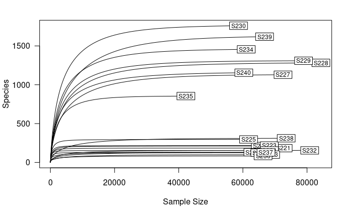

From the plot, the plateau was achieved for all samples indicating that the sequencing depth was robust.

## Diversity Statistics:

### Alpha (within sample) diversity

Alpha-diversity per sample

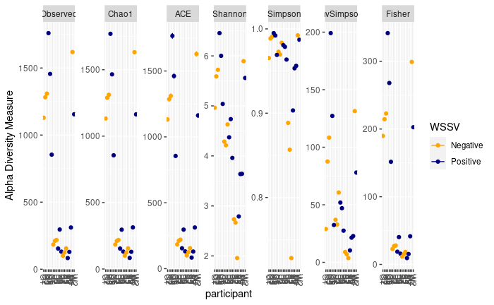

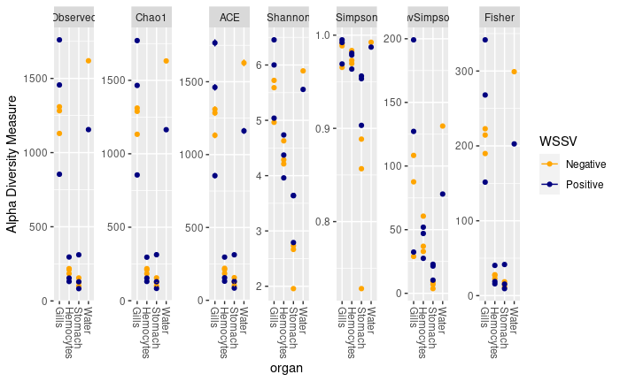

##Calculating alpha indices

```r
library(vegan) # reload vegan again
data_richness <- estimateR(ASV)                                            # calculate richness and Chao1 using vegan package

data_evenness <- diversity(ASV) / log(specnumber(OTU))                # calculate evenness index using vegan package

data_shannon <- diversity(ASV, index = "shannon")                          # calculate Shannon index using vegan package

data_simpson <- diversity(ASV, index = "simpson")

data_invsimp <- diversity(ASV, index = "invsimpson")

data_alphadiv <- cbind(df, t(data_richness), data_evenness, data_shannon, data_simpson, data_invsimp) # combine all indices in one data table

##rm(data_richness, data_evenness, data_shannon)
```

```r
alpha<-cbind(df$Site, t(data_richness), data_evenness, data_shannon, data_simpson, data_invsimp)
alpha_table <-data.frame(alpha)
alpha_table
```

|  | S.obs | S.chao1 | se.chao1 | S.ACE | se.ACE | data_evenness | data_shannon | data_simpson | data_invsimp |
| --- | --- | --- | --- | --- | --- | --- | --- | --- | --- |
| S221 | 184 | 184.0000 | 0.00000000 | 184.00000 | 2.409221 | 0.8219054 | 4.286184 | 0.9729378 | 36.951927 |
| S222 | 211 | 211.0000 | 0.24940688 | 211.36517 | 3.032174 | 0.7870571 | 4.212218 | 0.9695814 | 32.874618 |
| S223 | 218 | 218.3333 | 0.92580774 | 219.52778 | 1.857100 | 0.8597395 | 4.629263 | 0.9835051 | 60.624711 |
| S224 | 154 | 154.0000 | 0.49837398 | 154.56849 | 1.725472 | 0.8680360 | 4.372256 | 0.9807448 | 51.933975 |
| S225 | 296 | 296.0000 | 0.49915469 | 296.24871 | 3.482394 | 0.8322255 | 4.735662 | 0.9787278 | 47.009628 |
| S226 | 131 | 131.0000 | 0.00000000 | 131.00000 | 2.574093 | 0.8121761 | 3.959519 | 0.9636183 | 27.486362 |
| S227 | 1129 | 1132.6757 | 2.72242807 | 1132.51019 | 16.640855 | 0.7061672 | 4.963711 | 0.9654509 | 28.944298 |
| S228 | 1282 | 1288.7742 | 4.17012184 | 1286.02899 | 17.201041 | 0.7812008 | 5.590411 | 0.9885817 | 87.578346 |
| S229 | 1309 | 1311.2759 | 2.08213485 | 1311.01283 | 17.347560 | 0.7972270 | 5.721713 | 0.9907709 | 108.353501 |
| S230 | 1760 | 1770.3529 | 5.08077818 | 1766.84771 | 20.716746 | 0.8637419 | 6.454803 | 0.9949787 | 199.152314 |

[output cut: 10 more lines]

tidy format

```r
data_alphadiv_tidy <-
  data_alphadiv %>%
  gather(key   = alphadiv_index,
         value = obs_values,-participant, -WSSV, -organ,)

head(data_alphadiv_tidy)
```

|  | organ | WSSV | participant | alphadiv_index | obs_values |
| --- | --- | --- | --- | --- | --- |
| 1 | Hemocytes | Negative | H1 | S.obs | 184 |
| 2 | Hemocytes | Negative | H2 | S.obs | 211 |
| 3 | Hemocytes | Negative | H3 | S.obs | 218 |
| 4 | Hemocytes | Positive | H4 | S.obs | 154 |
| 5 | Hemocytes | Positive | H5 | S.obs | 296 |
| 6 | Hemocytes | Positive | H6 | S.obs | 131 |

[figure not shown]

[figure not shown]

## Statistical analyses

We will first test the effect of WSSV on the Shannon index using Kruskal-Wallis test.

```r
kruskal.test(data_shannon ~ WSSV , data = data_alphadiv)
```

```
    Kruskal-Wallis rank sum test

data:  data_shannon by WSSV
Kruskal-Wallis chi-squared = 0.28, df = 1, p-value = 0.5967
```

```r
kruskal.test(data_shannon ~ organ , data = data_alphadiv)
```

```
    Kruskal-Wallis rank sum test

data:  data_shannon by organ
Kruskal-Wallis chi-squared = 16.8, df = 3, p-value = 0.0007769
```

The results above tells us that there was no significant difference in Shannon diversity as a result of WSSV but there was a significant difference between organs.

## Analysis of Variance (ANOVA)

```r
anova <- aov(data_shannon ~ WSSV + organ, data = data_alphadiv)
summary(anova)
```

```
            Df Sum Sq Mean Sq F value   Pr(>F)
WSSV         1  0.625   0.625   2.658    0.124
organ        3 25.969   8.656  36.781 3.73e-07 ***
Residuals   15  3.530   0.235
---
Signif. codes:  0 ‘***’ 0.001 ‘**’ 0.01 ‘*’ 0.05 ‘.’ 0.1 ‘ ’ 1
```

Anova results indicate that there was no significant difference of bacterial community composition between presence and absence of WSSV but there was a significant difference between organs..

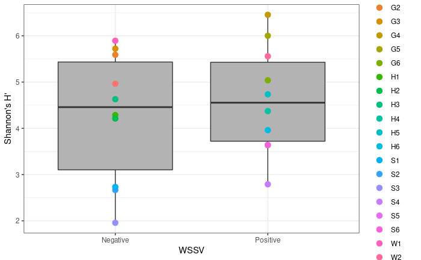

## Beta(between sample) diversity

```r
# Transform data to proportions as appropriate for Bray-Curtis distances
ps.prop <- transform_sample_counts(ps, function(otu) otu/sum(otu))
ord.nmds.bray <- ordinate(ps.prop, method="NMDS", distance="bray")
```

```
*** Solution reached
```

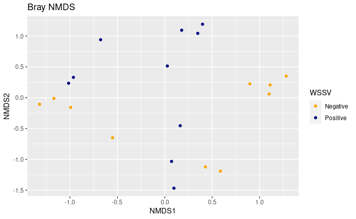

The plot above indicated that there is no distinction between WSSV positive and negative group.

## Phylum Bar plot:

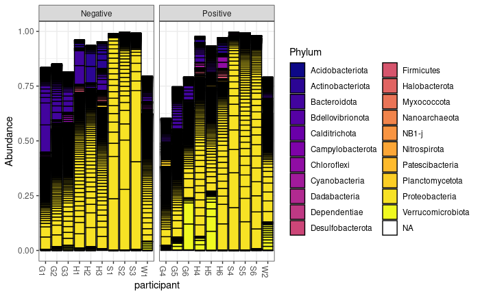

## Class Bar plot:

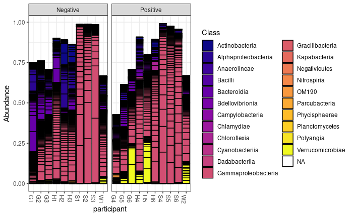

## Order Bar plot:

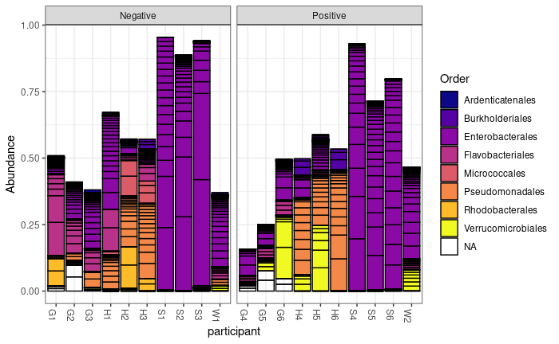

## Family Bar plot:

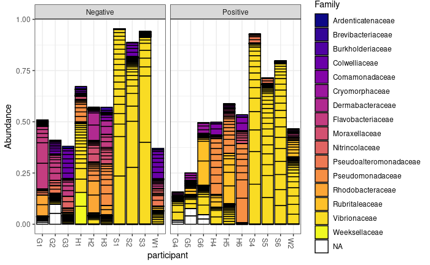

## Genus Bar plot:

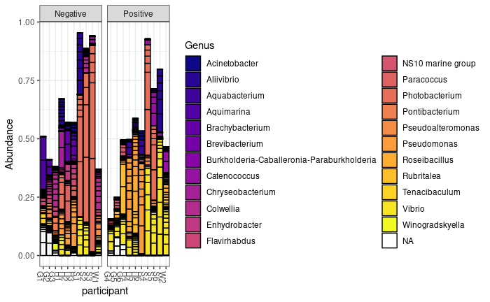

##Species Bar plot:

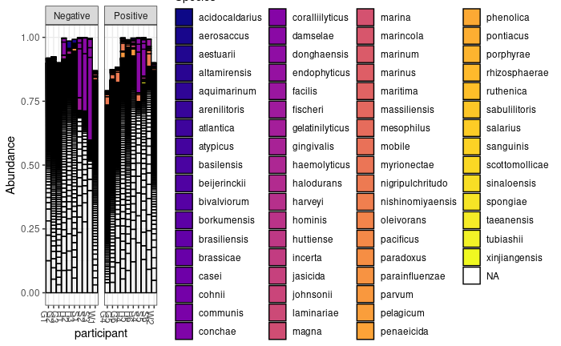

## Indepth analyses:

```r
data_phylo_filt <- filter_taxa(data_phylo, function(x) sum(x > 2) > (0.11 * length(x)), TRUE)
set.seed(1782) # set seed for analysis reproducibility
OTU_filt_rar = rarefy_even_depth(otu_table(data_phylo_filt), rngseed = TRUE, replace = FALSE) # rarefy the raw data using Phyloseq package
```

```
`set.seed(TRUE)` was used to initialize repeatable random subsampling.
Please record this for your records so others can reproduce.
Try `set.seed(TRUE); .Random.seed` for the full vector
...
```

```r
data_otu_filt_rar = data.frame(otu_table(OTU_filt_rar)) # create a separated file
data_phylo_filt_rar <- phyloseq(OTU_filt_rar, TAX, SAM) # create a phyloseq object
```

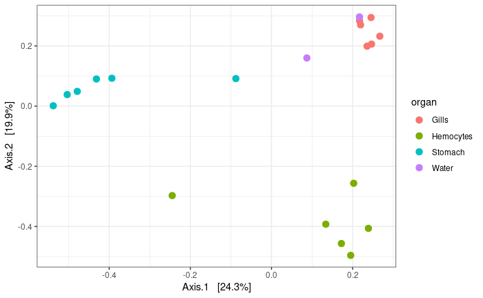

The PCOA plot represents every samples as a dot, which is colored according to target organ. First, this two-dimensions PCOA plot shows 44% of the total variance between the samples. Then, we can see that on both first and second axis, we can differentiate samples per organ. Through axis 1 the stomach samples are clearly separated from the other organs, while through axis 2, hemocytes samples are separated from the rest of the organs. Finally, we can see that the intra-variability between the gill samples is much lower than the intra-variability between the samples from other organs. However, we can observe distinct groups from the samples in each site, so the inter-variability between sites was high.

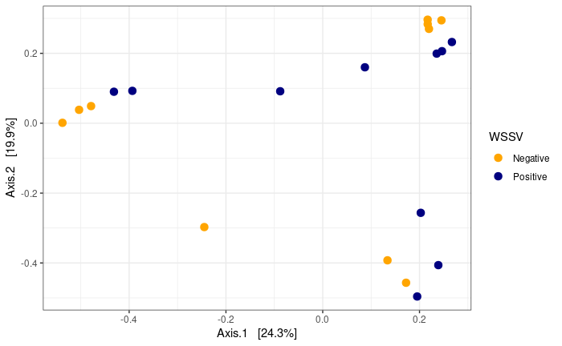

Combined variables; Distance based

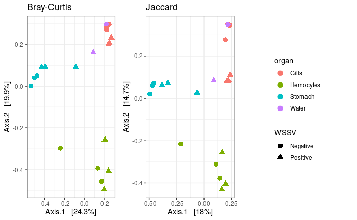

Phylogenetic based

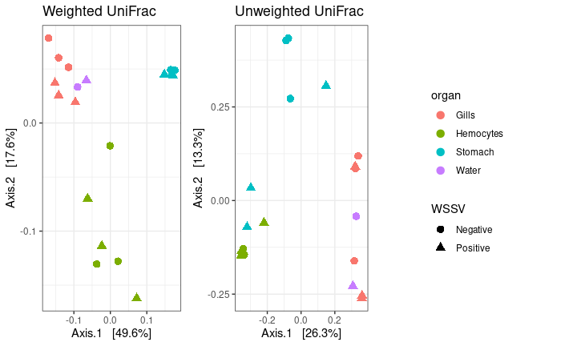

##Taxonomic Filtering In many biological settings, the set of all organisms from all samples are well-represented in the available taxonomic reference database. When (and only when) this is the case, it is reasonable or even advisable to filter taxonomic features for which a high-rank taxonomy could not be assigned. Such ambiguous features in this setting are almost always sequence artifacts that don’t exist in nature. It should be obvious that such a filter is not appropriate for samples from poorly characterized or novel specimens, at least until the possibility of taxonomic novelty can be satisfactorily rejected. Phylum is a useful taxonomic rank to consider using for this purpose, but other ranks may work effectively as well.

To begin, create a table of read counts for each Phylum present in the dataset. Show available ranks in the dataset

```r
rank_names(ps2)
```

```
[1] "Kingdom" "Phylum"  "Class"   "Order"   "Family"  "Genus"   "Species"
```

Create table, number of features for each phyla

```r
table(tax_table(ps2)[, "Phylum"], exclude = NULL)
```

```
                Acetothermia              Acidobacteriota             Actinobacteriota              Aenigmarchaeota               Armatimonadota
                           5                          176                          295                            2                            1
                Bacteroidota             Bdellovibrionota                Calditrichota             Campylobacterota                  Chloroflexi
                        1134                          272                           23                           14                          139
               Crenarchaeota                Cyanobacteria                 Dadabacteria                 Deinococcota                 Dependentiae
                           9                           66                           13                            9                           39
            Desulfobacterota              Elusimicrobiota            Entotheonellaeota               Fibrobacterota                   Firmicutes
                         111                            6                            6                            9                          101
              Fusobacteriota              Gemmatimonadota                Halobacterota              Hydrogenedentes                Iainarchaeota
                           2                           19                            4                           12                            1
            Latescibacterota             Margulisbacteria                       MBNT15                  Myxococcota                Nanoarchaeota
                          20                           17                            8                          204                          101
                       NB1-j                 Nitrospinota                 Nitrospirota              Patescibacteria              Planctomycetota
                          66                            2                            8                          303                         1075
              Proteobacteria SAR324 clade(Marine group B)                Spirochaetota                  Sumerlaeota             Thermoplasmatota
                        2774                            8                            6                            8                            1
           Verrucomicrobiota                        WPS-2                          WS2                 Zixibacteria                         <NA>
                         328                            8                            3                            1                          100
```

This shows a few phyla for which only one feature was observed. Those may be worth filtering, and we’ll check that next. First, notice that in this case, 100 features were annotated with a Phylum of NA. This features are probably artifacts in a dataset like this, and should be removed.

The following ensures that features with ambiguous phylum annotation are also removed. Note the flexibility in defining strings that should be considered ambiguous annotation.

```r
ps3 <- subset_taxa(ps2, !is.na(Phylum) & !Phylum %in% c("", "uncharacterized"))
```

A useful next step is to explore feature prevalence in the dataset, which we will define here as the number of samples in which a taxon appears at least once.

```r
# Compute prevalence of each feature, store as data.frame
prevdf <- apply(X = otu_table(ps3),
               MARGIN = ifelse(taxa_are_rows(ps3), yes = 1, no = 2),
               FUN = function(x){sum(x > 0)})
# Add taxonomy and total read counts to this data.frame
prevdf <- data.frame(Prevalence = prevdf,
                    TotalAbundance = taxa_sums(ps3),
                    tax_table(ps3))
```

Are there phyla that are comprised of mostly low-prevalence features? Compute the total and average prevalence of the features in each phylum.

```r
plyr::ddply(prevdf, "Phylum", function(df1){cbind(mean(df1$Prevalence),sum(df1$Prevalence))})
```

| Phylum | 1 | 2 |
| --- | --- | --- |
| Acetothermia | 1.400000 | 7 |
| Acidobacteriota | 1.403409 | 247 |
| Actinobacteriota | 1.474576 | 435 |
| Aenigmarchaeota | 1.000000 | 2 |
| Armatimonadota | 1.000000 | 1 |
| Bacteroidota | 1.781305 | 2020 |
| Bdellovibrionota | 1.367647 | 372 |
| Calditrichota | 1.260870 | 29 |
| Campylobacterota | 4.142857 | 58 |
| Chloroflexi | 1.482014 | 206 |

[output cut: 34 more lines]

Set filter conditions from the the table above.

```r
# Define phyla to be filter
filterPhyla <- c("SAR324 clade(Marine group B)", "WPS-2", "WS2", "NB1-j", "MBNT15")
# Filter entries with unidentified Phylum.
ps4<- subset_taxa(ps3, !Phylum %in% filterPhyla)
ps4
```

```
phyloseq-class experiment-level object
otu_table()   OTU Table:         [ 7316 taxa and 20 samples ]
sample_data() Sample Data:       [ 20 samples by 3 sample variables ]
tax_table()   Taxonomy Table:    [ 7316 taxa by 7 taxonomic ranks ]
phy_tree()    Phylogenetic Tree: [ 7316 tips and 7314 internal nodes ]
```

Ambiguous phyla were removed from the list

## Statistical test

To test whether the groups are different with respect to presence and absence of WSSV, a PERMANOVA statistical test was performed. For this a multivariate extension of ANOVA was used, as there are many ASVs that will be used in the test. The extension is based on distances between samples. The test compares distances of samples within the same group to distances of samples from different groups. If the distance between samples from the different groups is much larger than samples from the same group, we conclude that the groups are not equal.

In order to test the significance of the result, a permutation test was used. Thus all samples were randomly mixed over the groups and the test was repeated many times. If the ratio (between group distance / within group distance) is much larger for the original data than for the permutations, we conclude there is a statistical significant difference.

The test can be applied in combination with any distance measure. Here we use the Bray-Curtis and Jaccard’s distance as was also used for the PCoA above.

First, we will test if there is any significant effect of WSSV positive or negative samples and test differentiation by organ. For Bray dissimilarity

```r
# Permanova test using the vegan package
adonis2(data_otu_filt_rar~WSSV+organ, permutations=999, method="bray", data=metadata)
```

```
Permutation test for adonis under reduced model
Terms added sequentially (first to last)
Permutation: free
Number of permutations: 999

adonis2(formula = data_otu_filt_rar ~ WSSV + organ, data = metadata, permutations = 999, method = "bray")
         Df SumOfSqs      R2      F Pr(>F)
WSSV      1   0.6075 0.08368 2.1016  0.030 *
organ     3   2.3167 0.31908 2.6713  0.001 ***
Residual 15   4.3363 0.59724
Total    19   7.2605 1.00000
---
Signif. codes:  0 ‘***’ 0.001 ‘**’ 0.01 ‘*’ 0.05 ‘.’ 0.1 ‘ ’ 1
```

For Jaccard dissimilarty

```r
# Permanova test using the vegan package
set.seed=1
adonis2(data_otu_filt_rar~WSSV+organ, permutations=999, method="jaccard", data=metadata)
```

```
Permutation test for adonis under reduced model
Terms added sequentially (first to last)
Permutation: free
Number of permutations: 999

adonis2(formula = data_otu_filt_rar ~ WSSV + organ, data = metadata, permutations = 999, method = "jaccard")
         Df SumOfSqs      R2      F Pr(>F)
WSSV      1   0.6105 0.07563 1.7036  0.041 *
organ     3   2.0867 0.25848 1.9409  0.002 **
Residual 15   5.3757 0.66589
Total    19   8.0729 1.00000
---
Signif. codes:  0 ‘***’ 0.001 ‘**’ 0.01 ‘*’ 0.05 ‘.’ 0.1 ‘ ’ 1
```

The Total Sum of Squares is obtained from summing up all squared distances and dividing this by the number of samples - 1. The Residuals sum of squares (or within group sum of squares) is obtained by adding all squared distances of samples in the same group and divide this by the number of samples per group. The site sum of squares (or between group sum of squares) = SSTotal - SSResiduals. The F.model value then is obtained by the ratio of the Mean Squares (which are the Sum of squares divided by their degrees of freedom). The fraction of permuted results that provide a higher F value than the original data Pr(>F) represents the p-value which is significant when < 0.05. From the results above, WSSV had a significant effect in the composition of microbiota between samples and the organs also influences the microbiota composition.

## Differential abundance test

Here we used Benjamini-Hochberg as the default multiple-inference correction.

```r
WSSVdds <- phyloseq_to_deseq2(ps, ~ WSSV)
```

```
Warning in DESeqDataSet(se, design = design, ignoreRank) :
  some variables in design formula are characters, converting to factors
```

```r
WSSVdds <- estimateSizeFactors(WSSVdds, type = 'poscount')
WSSVdds <- DESeq(WSSVdds, test="Wald", fitType="parametric")
```

```
-- note: fitType='parametric', but the dispersion trend was not well captured by the
   function: y = a/x + b, and a local regression fit was automatically substituted.
   specify fitType='local' or 'mean' to avoid this message next time.
-- replacing outliers and refitting for 2477 genes
-- DESeq argument 'minReplicatesForReplace' = 7
-- original counts are preserved in counts(dds)
```

Investigate test results table

```r
res <- results(WSSVdds, cooksCutoff = FALSE)
alpha = 0.05
sigtab = res[which(res$padj < alpha), ]
sigtab = cbind(as(sigtab, "data.frame"), as(tax_table(ps)[rownames(sigtab), ], "matrix"))
head(sigtab)
```

|  | baseMean | log2FoldChange | lfcSE | stat | pvalue | padj | Kingdom | Phylum | Class | Order | Family | Genus | Species |
| --- | --- | --- | --- | --- | --- | --- | --- | --- | --- | --- | --- | --- | --- |
| ASV7 | 43.31663 | 8.535970 | 1.805606 | 4.727481 | 2.273226e-06 | 1.641480e-05 | Bacteria | Proteobacteria | Gammaproteobacteria | Enterobacterales | Vibrionaceae | Vibrio | NA |
| ASV11 | 36.66924 | 8.295325 | 1.809854 | 4.583423 | 4.574257e-06 | 3.246416e-05 | Bacteria | Proteobacteria | Gammaproteobacteria | Enterobacterales | Vibrionaceae | Vibrio | NA |
| ASV17 | 351.79270 | 6.151117 | 1.974663 | 3.115022 | 1.839313e-03 | 1.098282e-02 | Bacteria | Verrucomicrobiota | Verrucomicrobiae | Verrucomicrobiales | Rubritaleaceae | Roseibacillus | NA |
| ASV18 | 584.30745 | 6.364982 | 1.725544 | 3.688681 | 2.254197e-04 | 1.450628e-03 | Bacteria | Verrucomicrobiota | Verrucomicrobiae | Verrucomicrobiales | Rubritaleaceae | Rubritalea | NA |
| ASV25 | 544.30806 | -5.570503 | 1.737953 | -3.205210 | 1.349641e-03 | 8.257412e-03 | Bacteria | Bacteroidota | Bacteroidia | Flavobacteriales | Flavobacteriaceae | Flavirhabdus | NA |
| ASV28 | 44.72285 | -8.964921 | 2.383548 | -3.761166 | 1.691231e-04 | 1.105531e-03 | Bacteria | Proteobacteria | Alphaproteobacteria | Rhodobacterales | Rhodobacteraceae | Paracoccus | NA |

```r
dim(sigtab)
```

```
[1] 260  13
```

Let’s look at the OTUs that were significantly different between the two WSSV status.

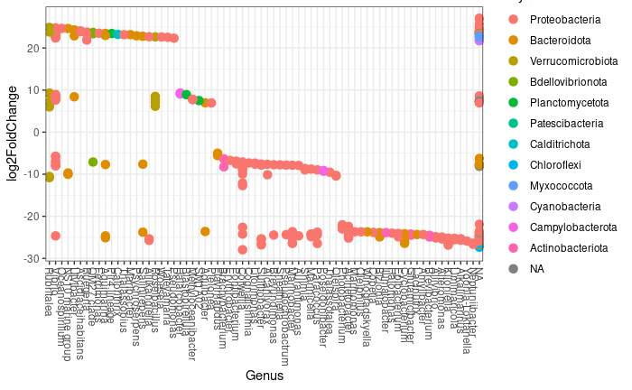